# Prosjekt 1 TMA4320 - Biofysikk

##### *Laget av Aksel Stenvold, Petter Stangeland og Tiril Hovstein Erikstad*

En kjent avbildningsmetode innen medisinsk forskning er MRI - såkalt "magnetic resonance imaging". Teknikken utnytter magnetiske egenskaper hos vannmolekyler som befinner seg i kroppen. Det som egentlig undersøkes når en bruker MR er den molekylære *diffusjonen*. Diffusjon forklarer hvordan molekyler fra et område med høy konsentrasjon beveger seg til et område med lavere konsentrasjon av molekyler.(ref) Ved oppnådd likevekt vil molekylene fremdeles bevege seg på en måte kalt virrevandring. Slik bevegelse eksisterer inni kroppens celler, mellom celler og inne i blodkar.

Hvis celler begynner å dele seg ukontrollert, oppstår det som kalles tumorer. Dette vil senke diffusjonen av vannmolekyler. Tanken er at MRI skal oppfange denne diffusjonsforskjellen for å kunne lokalisere tumoren. Vi ønsker i dette prosjektet å simulere virrevandring for å kunne identifisere og kartlegge tumorer ved bildeanalyse.

### Oppgave 1 - Frie virrevandrere i hhv. én og to dimensjoner.

Hvordan et stoff diffunderer vil avhenge av stoffets konsentrasjon. Det skjer én bevegelse per tidssteg, og bevegelsen er gitt ved en viss sannsynlighet $p_r$ for et steg til høyre, eller $p_l=1-p_r$ for et steg til venstre. I én dimensjon svarer dette til en partiell differensiallikning, gitt ved likning (5).

Vi ønsker å vise at hvis $\text{φ}$ er sannsynlighetstettheten til en normalfordeling med null forventningsverdi og varians $σ^2 = at$ , så løser dette ligning (5), gitt at a velges riktig.

$\varphi(x, t) = \frac{1}{\sqrt{2\pi at}}e^{-\frac{x^{2}}{2at}} \qquad (5)\quad \frac{\partial \varphi(x,t)}{\partial t} = D \frac{\partial^{2} \varphi(x,t)}{\partial x^{2}}, \quad D = \frac{(\Delta x)^{2}}{2\Delta t}$

Gitt fra oppgavetekst har vi $\Delta t = 1, \Delta x = 1 \Rightarrow D = \frac{1}{2}$

$\frac{\partial \varphi(x,t)}{\partial t} = \frac{x^{2}-at}{2\sqrt{2\pi}a^{\frac{3}{2}}t^{\frac{5}{2}}}e^{-\frac{x^{2}}{2at}}$ $\qquad\frac{\partial^{2} \varphi(x,t)}{\partial x^{2}} = \frac{x^{2}-at}{\sqrt{2\pi}(at)^{\frac{5}{2}}}e^{-\frac{x^{2}}{2at}}$

$\frac{x^{2}-at}{2\sqrt{2\pi}a^{\frac{3}{2}}t^{\frac{5}{2}}}e^{-\frac{x^{2}}{2at}} = D \frac{x^{2}-at}{\sqrt{2\pi}(at)^{\frac{5}{2}}}e^{-\frac{x^{2}}{2at}} \Leftrightarrow \frac{1}{2a^{\frac{3}{2}}t^{\frac{5}{2}}} = D \frac{1}{(at)^{\frac{5}{2}}} \Leftrightarrow \frac{1}{a^{\frac{3}{2}}} = \frac{1}{a^{\frac{5}{2}}} \Leftrightarrow a = 1$

Dermed ser vi at en normalfordelt stokastisk variabel med forventningsverdi null, og varians $\sigma^{2} = at$, $a = 1$ er en løsning på $(5)$.

```python
import numpy as np
import numpy.random
from numpy.typing import ArrayLike
import matplotlib.pyplot as plt
import pandas as pd
from scipy.optimize import curve_fit
from typing import Callable
from skimage import draw
from scipy import ndimage
```

Posisjonen som funksjon av tid kan dermed beskrives av en stokastisk prosess. Denne stokastiske prosessen gir grunnlag for en algoritme vi velger å kalle Algoritme 1. Vi bruker algoritmen til å lage en funksjon som simulerer bevegelsen for en enkelt virrevandrer i én dimensjon.

```python
def one_dimensional_rw(M: int, pr: float, dx: int = 1) -> tuple[np.ndarray, np.ndarray]:
    """
    Simulates a one dimensional random walk, M - 1 moves. O(n) time complexity

    Param:
    Int M number of moves + 1
    Float pr probability of moving to the right
    Int dx length of move, if none default to 1

    Output:
    Returns a tuple containing two numpy arrays with length M containing random walk positions and time stamps
    """
    positions = np.zeros(M)
    times = np.arange(M)
    uniform_dist = np.random.uniform(size=M-1) # I pseudokoden skal "tilfeldige tall være M - 1 lang, men det gir IndexError"
    for i in range(1, M):
        if uniform_dist[i - 1] < pr:
            positions[i] = positions[i - 1] + dx
        else:
            positions[i] = positions[i - 1] - dx

    return (times, positions)
```

Videre ønsker vi å fremstille bevegelsen grafisk. Fremstillingen inneholder bevegelsen for tre virrevandrere som funksjon av tid, med ulik $p_r$.

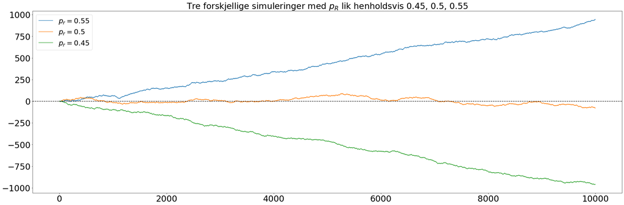

```python
fig, ax = plt.subplots(1)

x1, y1 = one_dimensional_rw(10000,0.55)
x2, y2 = one_dimensional_rw(10000,0.5)
x3, y3 = one_dimensional_rw(10000,0.45)

ax.plot(x1, y1, label='$p_{r} = 0.55$')
ax.plot(x2, y2, label='$p_{r} = 0.5$')
ax.plot(x3, y3, label='$p_{r} = 0.45$')
plt.axhline(y=0, color='black', linestyle='--')
ax.set_title("Tre forskjellige simuleringer med $p_{R}$ lik henholdsvis 0.45, 0.5, 0.55", fontsize=30)



fig.set_size_inches(30, 10)
fig.tight_layout()
ax.legend(loc=2, prop={'size': 25})
ax.tick_params(axis='both', which='major', labelsize=30)
plt.show()
```

Ved høy verdi for M, ser en at virrevandrerene beveger seg i den retningen med høyest sannsynlighet. Ved lavere verdi for M er det vanskelig å konkludere at sannsynligheten har en innvirkning, da bevegelsen er mer tilfeldig.

### Algoritme 1

Det er nyttig å kunne simulere bevegelsen til et gitt antall, N, virrevandrere samtidig. For å gjøre dette må algoritmen modifiseres.

```python
def n_one_dimensional_rw(M: int, N: int, pr: float, dx: int = 1) -> tuple[np.ndarray, np.ndarray]:
    """
    Simulates N one dimensional random walks, M - 1 moves

    Param:
    Int M number of moves + 1
    Int N number of random walks
    Float pr probability of moving to the right
    Int dx length of move, if none default to 1

    Output:
    Returns a tuple containing one 2d numpy array where the individual vectors contain positions for one random walk and one array containing time stamps
    """
    positions = np.zeros((N, M)) # Hver rad en virrevandrer og hver kolonne
    for random_walk in range(N):
        positions[random_walk] = one_dimensional_rw(M, pr, dx)[0]
    return positions
```

Denne algoritmen er relativt treg for høyere verdier av M og N. Derfor forbedres den til Algoritme 2 vist under, ved hjelp av innebygde numpy-funksjoner som reduserer kjøretiden.

### Algoritme 2

```python
def improved_n_one_dimensional_rw(M: int, N: int, pr: float, dx: int = 1) -> tuple[np.ndarray, np.ndarray]:
    """
    Simulates N one dimensional random walks, M - 1 moves

    Param:
    Int M number of moves + 1
    Int N number of random walks to simulate
    Float pr probability of moving to the right
    Int dx length of move, if none default to 1

    Output:
    Returns a tuple containing one 2d numpy array where the individual vectors contain positions for one random walk and one array containing time stamps
    """
    positions = np.zeros((N, M)) # Hver rad en virrevandrer og hver kolonne
    time = np.arange(M)
    for random_walk in range(N):
        positions[random_walk] = np.cumsum(np.random.binomial(1, pr, M) * 2 - 1)
    return positions, time
```

### Sammenligning av kjøretid

Som nevnt vil det å bruke innebygde funksjoner i Python som numpy forkorte et kodesegments kjøretid men i tillegg vil vi gå litt nærmere inn på hvordan oppbygningen av koden påvirker kjøretiden.

```python
%%timeit
M = 1000
N = 1000
pr = 0.5

n_one_dimensional_rw(M, N, pr)
```

```
596 ms ± 36.9 ms per loop (mean ± std. dev. of 7 runs, 1 loop each)
```

```python
%%timeit
M = 1000
N = 1000
pr = 0.5

improved_n_one_dimensional_rw(M, N, pr)
```

```
36.7 ms ± 4.15 ms per loop (mean ± std. dev. of 7 runs, 10 loops each)
```

Som vi ser er den forbedrede algoritmen mye raskere sammenlignet med den første. For å forklare hvorfor den nye algoritmen er raskere må vi studere tidskompleksitet til algoritmene ved bruk av stor O-notasjon.

Algoritme 1 består av for-løkke med en for-løkke som inneholder en if-else-setning inni seg.

```
for i -> N:

    for -> M:

        if:
            operasjon

        else:
            operasjon
```

$\mathcal{O}(N \cdot N \cdot (k + j)) = \mathcal{O}(N \cdot N) = \mathcal{O}(N^{2})$ dermed kjører algoritmen i kvadratisk tidskompleksitet.

Algoritme 2 består av kun en for-løkke med operasjoner inni seg.

```
for i -> N:

    numpy operasjon
```

Vi vet ikke tidskompleksiteten til numpy funksjonen, men ved et verste tilfelle tror vi ikke det er galt å si at operasjonen kjører i $\mathcal{O}(N)$ Men det betyr også er i bedre tilfeller er tidskompleksiteten til den forbedrede  
algoritmen er bedre i de tilfellene etter som den første alltid kjører i $\mathcal{O}(N^{2})$ tid.

$\mathcal{O}(N \cdot N) = \mathcal{O}(N^{2})$

Men det vi ikke har tatt hensyn til er at mange operasjoner i numpy er skrevet i C slik at de er mye raskere enn python siden man ungår trege for-løkker i python og dynamisk type sjekking osv.

I tilegg er en stor forskjell mellom de to algoritmene er at den forbedrede har mye ferre operasjons-kall slik at den trenger å gjøre ferre operasjoner som ofte også betyr raskere kode.

## Empirisk varians

```python
def f(x, a):
    return a*x


def linear_regression(positions: ArrayLike, time: ArrayLike, f: Callable) -> tuple[np.ndarray, np.ndarray]:
    """
    Plots variance in position between random walk positions passed in the positions argument

    Param:
    np.ndarray positions 2d array with nth random walk as the nth nd.array
    np.ndarray time array with time stamps

    Output:
    Returns a tuple containing y-values of the linear regression and array containing time stamps
    """
    varians = np.apply_along_axis(np.var, 0, positions)
    popt, pcov = curve_fit(f, time, varians)
    return (f(time, popt[0]), varians, popt[0])
```

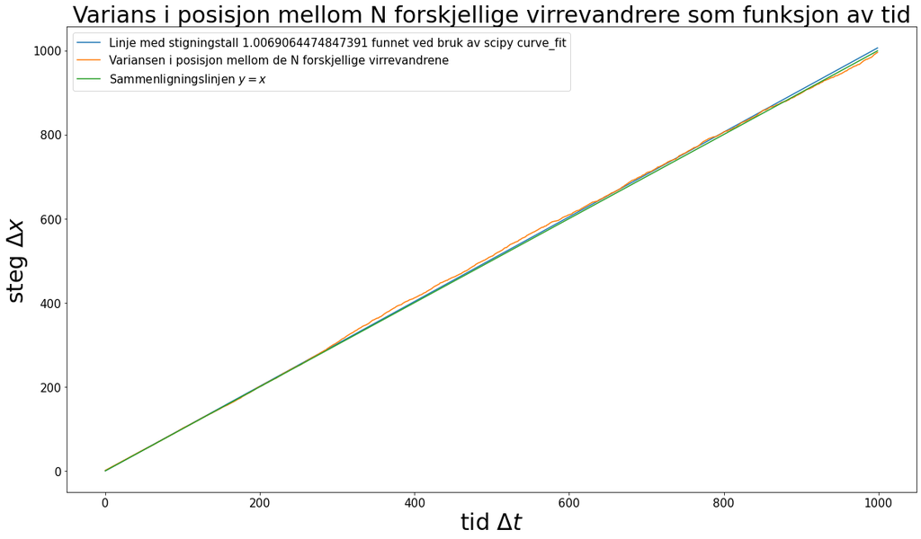

```python
M = 1000
N = 10000
pr = 0.5

positions, time = improved_n_one_dimensional_rw(M, N, pr)

y_values, varians, slope = linear_regression(positions, time, f)

fig, ax = plt.subplots(1)

ax.plot(time, y_values, label=f"Linje med stigningstall {slope} funnet ved bruk av scipy curve_fit")
ax.plot(time, varians, label='Variansen i posisjon mellom de N forskjellige virrevandrene')
ax.plot(range(len(time)), time, label='Sammenligningslinjen $y=x$')
ax.set_xlabel("tid $\Delta t$", fontsize=30)
ax.set_ylabel("steg $\Delta x$", fontsize=30)
ax.set_title("Varians i posisjon mellom N forskjellige virrevandrere som funksjon av tid", fontsize=30)

ax.legend(loc=2, prop={'size': 15})
ax.tick_params(axis='both', which='major', labelsize=15)
fig.set_size_inches(17, 10)
fig.tight_layout()
plt.show()
```

### To dimensjoner

Vi ønsker å utvide simuleringen til å gjelde for to dimensjoner og modifiserer koden deretter. Deretter plotter vi bevegelsen for fire virrevandrere i hhv. isotropt og anisotropt system.

```python
def two_dimensional_rw(M: int, pr: float, pu: float, dx: int = 1) -> np.ndarray:
    """
    Simulates a two dimensional random walk, M - 1 moves.

    Param:
    Int M number of moves + 1
    Float pr probability of moving to the right
    Float pu probability of moving up
    Int dx length of move, if none default to 1

    Output:
    Returns a array with dimensions (M x 2) with x-coordinates in the col 1 and y-coordinates in col 2
    """
    positions = np.zeros((M + 1, 2), dtype=int)
    positions[1:,0] = np.random.randint(0, 2, M)
    positions[1:,1] = np.where(positions[1:,0] == 0, 1, 0)
    positions[1:,0] *= np.random.binomial(1, pr, M)*2 - 1
    positions[1:,1] *= np.random.binomial(1, pu, M)*2 - 1
    path = np.cumsum(positions, axis = 0)
    return path

def plot_n_two_dimensional_bm(M: int, N: int, ax: plt.axes, pr: float, pu: float, dx: int = 1) -> None:
    """
    Plots n random walk simulations in 2d system using the v2_two_dimensional_bm function

    Param:
    Int M number of moves + 1
    Int N number of random walks to simulate
    Float pr probability of moving to the right
    Float pu probability of moving up
    Int dx length of move, if none default to 1

    Output:
    Returns none
    """
    for i in range(N):
        pos = two_dimensional_rw(M, pr, pu, dx)
        ax.plot(pos[:,0], pos[:,1])
```

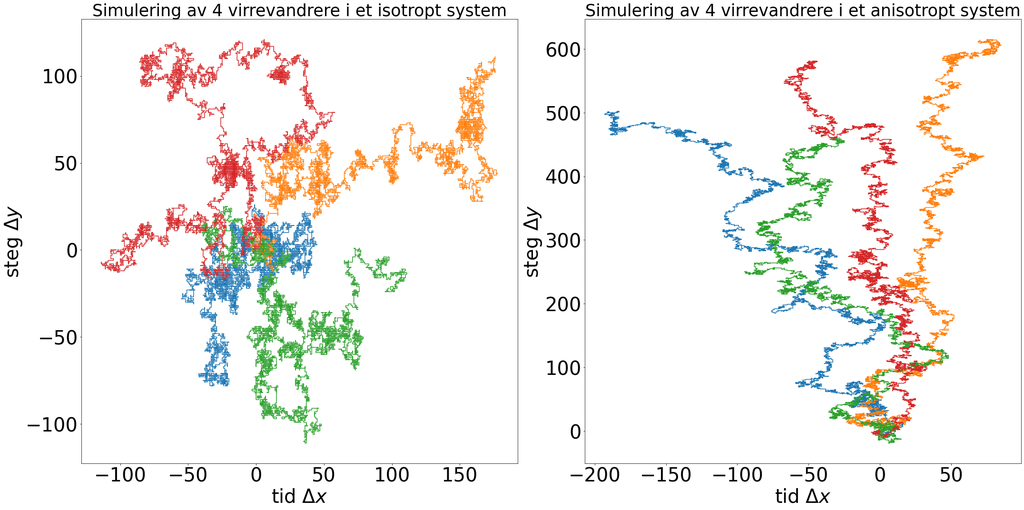

```python
M = 10000
N = 4
pr = 0.5
pu = 0.5

fig, ax = plt.subplots(1, 2)

for i in range(N):
        pos = two_dimensional_rw(M, pr, pu)
        ax[0].plot(pos[:,0], pos[:,1])

pu = 0.55

for i in range(N):
        pos = two_dimensional_rw(M, pr, pu)
        ax[1].plot(pos[:,0], pos[:,1])

ax[0].set_title('Simulering av 4 virrevandrere i et isotropt system', fontsize=35)
ax[0].tick_params(axis='both', which='major', labelsize=40)
ax[0].set_xlabel("tid $\Delta x$", fontsize=40)
ax[0].set_ylabel("steg $\Delta y$", fontsize=40)


ax[1].set_title('Simulering av 4 virrevandrere i et anisotropt system', fontsize=35)
ax[1].tick_params(axis='both', which='major', labelsize=40)
ax[1].set_xlabel("tid $\Delta x$", fontsize=40)
ax[1].set_ylabel("steg $\Delta y$", fontsize=40)
fig.set_size_inches(30, 15)
fig.tight_layout()
plt.show()
```

Det er en merkbar forskjell i virrevandrerenes bevegelse som funksjon av tid for de to systemene. Det er hensiktsmessig å studere aksene for hver enkelt figur. Mens intervallet for bevegelse i x-retning er lik for de to systemene, har det anisotrope systemet høyere sannsynlighet for bevegelse i positiv y-retning enn i negativ y-retning. Dermed er bevegelsen for en virrevandrer i det anisotrope systemet mer spredt i y-retning enn det isotrope systemet.

### Virrevandrer returnerer til origo

Vi ønsker i denne oppgaven avslutningsvis å undersøke sannsynligheten for at en virrevandrer returnerer til origo minst én gang i løpet av et tidsintervall. Sannsynligheten defineres som $P(x=0,t)$ og vi approksimerer $t \rightarrow \infty$ ved å sette M tilstrekkelig stor. Andelen virrevandrere som returnerer til origo minst én gang ila. tid $t$ settes som $n(t)$.

```python
def has_returned_to_origin_by_t_2d(positions: ArrayLike) -> bool:
    """
    Checks if the path, given as an argument, of a random walk has returned to the origin in 2 dimensions

    Param:
    Arraylike positions list with (x, y)-coordinates of a random walk

    Output:
    returns a boolean, True if the random walk has returned to the origin and False otherwise
    """
    return len(np.where((positions[:,0] == 0) & (positions[:,1] == 0))[0]) > 1

def has_returned_to_origin_by_t_1d(positions: ArrayLike) -> bool:
    """
    Checks if the path, given as an argument, of a random walk has returned to the origin in 1 dimension

    Param:
    Arraylike positions list with x-coordinates of a random walk

    Output:
    returns a boolean, True if the random walk has returned to the origin and False otherwise
    """
    return len(np.where(positions==0)[0]) > 0


def n_2d(t: int, N: int) -> float:
    """
    Simulates N random walks for t steps and uses has_returned_to_origin_by_t_2d to see how many return to origin

    Param:
    Int t how long to simulate the N simulations
    Int N how many random walks to simulate

    Output:
    returns percentage of random walks which have returned to the origin by time t
    """
    S = 0
    for i in range(N):
        pos = two_dimensional_rw(t, 0.5, 0.5)
        if has_returned_to_origin_by_t_2d(positions=pos):
            S += 1
    return S / N


def n_1d(t: int, N: int) -> float:
    """
    Simulates N random walks for t steps and uses has_returned_to_origin_by_t_1d to see how many return to origin

    Param:
    Int t how long to simulate the N simulations
    Int N how many random walks to simulate

    Output:
    returns percentage of random walks which have returned to the origin by time t
    """
    S = 0
    for i in range(N):
        pos = np.cumsum(np.random.binomial(1, pr, t) * 2 - 1)
        if has_returned_to_origin_by_t_1d(positions=pos):
            S += 1
    return S / N
```

I én dimensjon: $P(x=0,t=1)=0$. Dette er fordi virrevandreren starter i origo og kan dermed ikke være i origo etter ett tidssteg.

I to dimensjoner: $P(x=0,t=2)=1/4$. Dette fordi for at virrevandreren skal befinne seg i origo etter to tidssteg må det andre skrittet være motsatt det første.

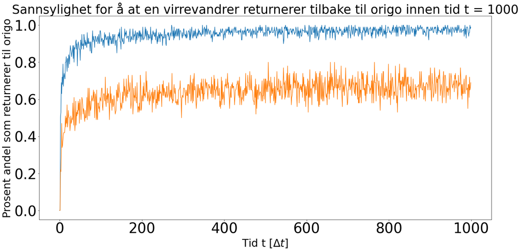

```python
def plot_n_1d(t0: int, t: int, N: int, ax):
    t_arr = np.arange(t0,t)
    N_arr = np.full(len(t_arr),N)
    n = np.vectorize(n_1d)
    ax.plot(t_arr,n(t_arr,N_arr))

def plot_n_2d(t0: int, t:int , N: int, ax):
    t_arr = np.arange(t0,t)
    N_arr = np.full(len(t_arr),N)
    n = np.vectorize(n_2d)
    ax.plot(t_arr,n(t_arr,N_arr))

t0 = 0
t = 1000
N = 100

fig, ax = plt.subplots()
ax.set_title(f'Sannsylighet for å at en virrevandrer returnerer tilbake til origo innen tid t = {t}', fontsize=35)
ax.tick_params(axis='both', which='major', labelsize=40)
ax.set_xlabel("Tid t [$\Delta t$]", fontsize=30)
ax.set_ylabel("Prosent andel som returnerer til origo", fontsize=30)

fig.set_size_inches(20, 10)
fig.tight_layout()
plot_n_1d(t0, t, N, ax)
plot_n_2d(t0, t, N, ax)
plt.show()
```

N, som her er antall virrevandrere, avgjør hvor nøyaktig sannsynligheten er, mens M øker sannsynligheten for at virrevandreren er innom origo.

I én dimensjon vil grafen tilnærmes 1, men for å gjøre det i 2D kreves langt flere tidssteg. Øker man tidsstegene i 2D vil ikke bare kjøretiden øke, men en må også øke N for at nøyaktigheten skal samsvare. Da blir kjøretiden for urimelig lang. Her har vi dermed valgt 1000 på tidssteg og 100 virrevandrere.

## Oppgave 2 - Diffusjon av vannmolekyler i hjernen

I resten av prosjektet vil vi bruke konstantene presentert under for å etterlikne realistisk diffusjon av vannmolekyler i hjernen. Diffusjonskonstanten i $\textit {friskt}$ vev utregnes av funksjonen diffconstant.

```python
DELTA_X = 0.004 #mm
DELTA_T = 0.01 #s

# * 5000 skalering

DELTA_X = 20 #mm
DELTA_T = 50 #
```

```python
def diffconstant(DELTA_X, DELTA_T):
    D = ((DELTA_X)**2)/2*DELTA_T
    return D

print(diffconstant(DELTA_X, DELTA_T))
```

```
10000.0
```

Vi skal videre betrakte tumorer der diffusjonskonstanten er lavere. Vi betrakter sirkulære tumorer med radius $r$ og diffusjonskonstant redusert med en tumorkoeffisient $t_{k}$. Denne koeffisienten vil redusere skrittlengden $\Delta x$ med faktoren $\sqrt{t_{k}}$ slik at hvis vi har en virrevandrer B med skrittlengde $\Delta x_{0}$ som befinner seg innenfor en tumor T med tumorkoeffisient $t_{k}$ vil skrittlengden $\Delta x$ til B være $\Delta x = \Delta x_{0} \sqrt{t_k}$ innenfor T sitt areal.

```python
def inside_tumor(pos:tuple[float, float], tumors: ArrayLike) -> tuple[int, ArrayLike]:
    """
    Help method used to as a check to see if a pair of (x, y)-coordinates are inside the radius of the tumors in the system

    Param:
    Tuple pos Arraylike of length 2 containing x and y coordinates
    Arraylike tumor_coords with shape (m, 4) containing center x- and y-coordinates, radius and tk-factor as columns and the m tumors as rows

    Output:
    Returns the number of tumors that the positional (x, y)-coordinates currently is inside of as well as the corresponding tk values of these tumors
    """
    number_of_tumors = 0
    tks = []
    for tumor in tumors:
        d = np.sqrt((pos[0] - tumor[0])**2 + (pos[1] - tumor[1])**2)
        if d < tumor[2]:
            number_of_tumors += 1
            tks.append(tumor[3])
    return number_of_tumors, tks


def tumors_grid_start_periodic(L: int, m: int, r: int, tks: ArrayLike) -> tuple[np.ndarray, np.ndarray]:
    """
    Generates m random tumors with radius r within the L x L square with corners in (0, 0) and (L, L) as well as changes values of grid according to the tumor positions

    Param:
    Int L side length of square
    Int m number of tumors
    Int r radius of tumors

    Output:
    Returns a tuple containg a list with length m with each element containing center coordinates and radius [x_center, y_center, radius]
    and numpy 2d array with shape (L, L) containing tumors as a depth image (imshow to visualize) tumors
    """
    tumors = initialize_tumors_periodic(L, m, r, tks)
    grid = np.ones((L + 1, L + 1), dtype=float)
    for center in tumors:
        rr, cc = draw.disk((center[1], center[0]), center[2], shape=grid.shape)
        grid[rr, cc] = grid[rr, cc] * np.sqrt(0.1)
    return (tumors, grid)


def initialize_tumors_periodic(L: int, m: int, r:int, tk: ArrayLike) -> np.ndarray:
    """
    Generates m random tumors with radius r within the L x L square with corners in (0, 0) and (L, L)

    Param:
    Int L side length of square
    Int m number of tumors
    Int r radius of tumors
    Arraylike tk list of tumor coefficients

    Output:
    returns a numpy array with shape (m, 4) containing center coordinates, radius and tumorcoefficient
    """
    tumors = np.zeros((m, 4))
    for i in range(m):
        tumor = np.random.randint(0, L, 2)
        tumors[i][0] = tumor[0]
        tumors[i][1] = tumor[1]
        tumors[i][2] = r
        tumors[i][3] = tk[i]
    return tumors
```

### Valg av grensebetingelser

Videre i oppgaven vil vi lage et $L \times L$ system med m tumorer med periodiske grensebetingler slik at systemet, topologisk sett, blir avbildet på en torus. Dvs. at dersom en virrevandrer beveger seg forbi L i x-retning, vil virrevandrer gå videre på høyre siden (mot venstre) og tilsvarende med opp og ned. Grunnen for at vi valgte å benytte periodiske grensebetingelser er at det blir lettere å simulere systemet vårt for mindre størrelser i tilegg til at en simulasjon av en virrevandrer vil måtte bruke mye færre steg for å teke hele arealet til systemet vårt. I motsetning hvis vi hadde hatt et veldig stort system ville det kunnet tatt utrolig lang tid for virrevandren vårt å tekke hele systemet med f.eks åpne grensebetingelser.

```python
def tumor_two_dimensional_bm_periodic(M: int, L: int, tumors: ArrayLike, pr: float, pu: float, dx: int = 1) -> tuple[ArrayLike, ArrayLike]:
    """
    Simulates a random walk with M steps in a periodic (L x L) system with m tumors and probability pr of moving to the right and pu for moving up with a step length of dx

    Param:
    Int M number of steps
    Int L side lengths of system
    Arraylike tumors shape (m, 4), m tumors containing center coordinates, radius and tumor coefficient
    Float pr probability of moving to the right
    Float pu probability of moving up
    Int dx step length

    Output:
    Returns a tuple containg x-positions and y-positions of the random walk
    """
    positions_x = np.zeros(M) + int(L/2)
    positions_y = np.zeros(M) + int(L/2)
    timeline = np.arange(1, M)
    for time in timeline:
        direction = np.random.choice((0, 1)) # Either index 0 for positions_x or index 1 for positions_y
        if direction:
            vertical_step = np.random.choice((1, -1), p=[pu, 1 - pu]) * DELTA_X
            tumor_factor, tks = inside_tumor((positions_x[time - 1], positions_y[time - 1]), tumors)
            tk_product = np.prod(tks)
            if tk_product == 0: tk_product = 1
            vertical_step = vertical_step * np.sqrt(tk_product)
            positions_y[time] = positions_y[time - 1] + vertical_step
            positions_x[time] = positions_x[time - 1]
            if positions_x[time] >= L:
                positions_x[time] = positions_x[time] - L
            elif positions_x[time] <= 0:
                positions_x[time] = positions_x[time] + L

            if positions_y[time] >= L:
                positions_y[time] = positions_y[time] - L
            elif positions_y[time] <= 0:
                positions_y[time] = positions_y[time] + L
        else:
            horizontal_step = np.random.choice((1, -1), p=[pr, 1 - pr]) * DELTA_X
            tumor_factor, tks = inside_tumor((positions_x[time - 1], positions_y[time - 1]), tumors)
            tk_product = np.prod(tks)
            if tk_product == 0: tk_product = 1
            horizontal_step = horizontal_step * np.sqrt(tk_product)
            positions_y[time] = positions_y[time - 1]
            positions_x[time] = positions_x[time - 1] + horizontal_step
            positions_y[time] = positions_y[time - 1]

            if positions_x[time] >= L:
                positions_x[time] = positions_x[time] - L
            elif positions_x[time] <= 0:
                positions_x[time] = positions_x[time] + L

            if positions_y[time] >= L:
                positions_y[time] = positions_y[time] - L
            elif positions_y[time] <= 0:
                positions_y[time] = positions_y[time] + L

    abs_d_data = np.abs(np.diff(positions_x))
    mask = np.hstack([ abs_d_data > abs_d_data.mean()+3*abs_d_data.std(), [False]])
    positions_x = np.ma.MaskedArray(positions_x, mask)
    abs_d_data = np.abs(np.diff(positions_y))
    mask = np.hstack([ abs_d_data > abs_d_data.mean()+3*abs_d_data.std(), [False]])
    positions_y = np.ma.MaskedArray(positions_y, mask)

    return (positions_x, positions_y)
```

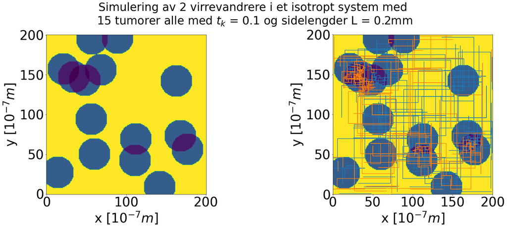

```python
M=1000
N=2
L=200
m=15
DELTA_X = 40
tk = 0.1
r=20
pr=0.5
pu=0.5

tks = np.ones(m) * tk
tumors, grid = tumors_grid_start_periodic(L, m, r, tks)

fig, ax = plt.subplots(1, 2)
ax[0].imshow(grid, origin='lower')
ax[1].imshow(grid, origin='lower')

for i in range(N):
    posx, posy = tumor_two_dimensional_bm_periodic(M, L, tumors, pr, pu, DELTA_X)
    ax[1].plot(posx, posy)


ax[0].tick_params(axis='both', which='major', labelsize=40)
ax[0].set_xlabel("x [$10^{-7} m$]", fontsize=40)
ax[0].set_ylabel("y [$10^{-7} m$]", fontsize=40)


ax[1].tick_params(axis='both', which='major', labelsize=40)
ax[1].set_xlabel("x [$10^{-7} m$]", fontsize=40)
ax[1].set_ylabel("y [$10^{-7} m$]", fontsize=40)
ax[1].set_xlim([0, L])
ax[1].set_ylim([0, L])
fig.suptitle('Simulering av 2 virrevandrere i et isotropt system med \n' + f'{m}' + ' tumorer alle med $t_{k}$ = ' + f'{tk}' + ' og ' + f'sidelengder L = {L/1000}mm', fontsize=35)
fig.set_size_inches(25, 10)
fig.tight_layout()
plt.show()
```

Som vi ser fra figuren ser man store forskjeller i konsentrasjonen av virrevandrerne i områder uten tumorer, en tumorer og hvor to eller flere tumorer overlapper. Senere skal vi introdusere intensiteten som forteller oss hvor det er høyere konsentrasjon av virrevandrere så vi kan prøve å se hvor tumorerene befinner seg.

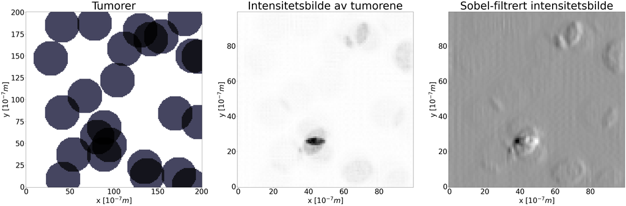

```python
M=10000
N=50
L=200
m=25
r=20
pr=0.5
pu=0.5
DELTA_X = 8
n = 100
tks = np.random.uniform(0.3, 0.45, m)
tumors, grid = tumors_grid_start_periodic(L, m, r, tks)

fig, ax = plt.subplots(1, 3)
ax[0].imshow(grid, cmap = 'bone', origin='lower')
ax[0].set_title('Tumorer', size = 60)
ax[0].set_xlabel("x [$10^{-7} m$]", fontsize=40)
ax[0].set_ylabel("y [$10^{-7} m$]", fontsize=40)
ax[0].tick_params(axis='both', which='major', labelsize=40)

hist = np.histogram2d([], [], bins=n)[0]
for i in range(N):
    posx, posy = tumor_two_dimensional_bm_periodic(M, L, tumors, pr, pu)
    hist += np.histogram2d(posy, posx, bins=n, density=True)[0]

ax[1].imshow(hist, cmap = 'Greys', origin='lower')
ax[1].set_title('Intensitetsbilde av tumorene', size = 60)
ax[1].set_xlabel("x [$10^{-7} m$]", fontsize=40)
ax[1].set_ylabel("y [$10^{-7} m$]", fontsize=40)
ax[1].tick_params(axis='both', which='major', labelsize=40)

ax[2].imshow(ndimage.sobel(hist), cmap = 'Greys', origin='lower')
ax[2].set_title('Sobel-filtrert intensitetsbilde', size = 60)
ax[2].set_xlabel("x [$10^{-7} m$]", fontsize=40)
ax[2].set_ylabel("y [$10^{-7} m$]", fontsize=40)
ax[2].tick_params(axis='both', which='major', labelsize=40)
fig.set_size_inches(60, 30)
plt.show()
```

Figur 2 viser intensitetsplottet. Den kan brukes til å detektere tumorenes posisjon og størrelse. Utslaget på intensitetsplottet avhenger av hvor mye tid en virrevandrer tilbringer innenfor et område. Ettersom diffusjonskonstanten er lavere inni en tumor vil dermed virrevandreren tilbringe mer tid der konsentrasjonen av tumorer er høy. Dette synes grafisk ved en kontrast/mørkere farge i intensitetsplottet, som videre kan tydeliggjøres ved hjelp av Sobel-filteret.

Økt antall steg M vil i høyere grad sørge for at hver enkelt tumor dukker opp på intensitetsplottet. Økt antall virrevandrere N vil ha samme effekt og hjelpe på å lokalisere tumorer som ikke overlappes av andre tumorer. I dette plottet starter i midlertid alle virrevandrerne fra midten. Dette kan medføre at tumorene som eventuelt finnes i midten av simuleringen får høyere intensitet enn tumorer i utkant av bildet.

Begrensninger for verdiene settes av kjøretid på koden. En oppdager fort at å simulere for fler enn 100 virrevandrere vil kreve lang kjøretid.